# VERSE User Manual

Junhyong Kim Lab, University of Pennsylvania Gerben Voshol, GenomeScan B.V.

# 1 General Description

VERSE is designed for high-performance read summarization for next generation sequencing. VERSE is 50x faster than HTSeq when computing the same gene counts. It introduces a novel, hierarchical assignment scheme, which allows simultaneous quantification of multiple feature types or annotation levels without repeatedly assigning reads. There is also a set of parameters the user can use to fine-tune the assignment logic. VERSE can be readily incorporated into any existing RNA-Seq analysis pipelines.

- Input file format: BAM/SAM produced by read alignment tools such as STAR, annotation file (GTF format).
- Output files: Feature/Gene counts file with the same format as HTSeq/featureCounts, a summary file summarizing the results, read assignment details for each read/read pairs if user specifies `-R`.
- Usage: `./verse [options] -a <annotation_file> -o <output_file> input_file`

A sample command:

```
./verse -a testdata/test.gtf -t 'exon' -g gene_id -z 3 -s 1 -o testdata/intersection_nonempty.stranded.paired testdata/PE.sam
```

A sample hierarchical assign command:

```
./verse -a testdata/test.gtf -t 'exon;intron;xine' -g gene_id -z 3 -o testdata/intersection_nonempty.unstranded.paired.hierarchical testdata/PE.sam
```

# 2 Parameter Description

## 2.1 Required Parameters

```
    -a <input>  Give the name of the annotation file. The program currently only
                supports GTF format.

    -o <input>  Give the general name of the output file, e.g., 'Sample_A'.
                The summary file will be named 'Sample_A.summary.txt.'
                The file containing gene counts will be named 'Sample_A.exon.txt',
                'Sample_A.intron.txt', etc.

    input_file  Give the name of input read file that contains the read mapping
                results. Format of input file is automatically determined (SAM/BAM)
                If it is paired-end data, the file MUST be name-sorted, otherwise
                the user MUST specify -S, or use samtools to sort it by name.
```

## 2.2 Optional Parameters:

[output not shown]

[output cut: 50 more lines]

```
    --minDifAmbiguous <int>     This option can only be used in VERSE-cover_length
                mode. When the read or the read pair hits more than one genes,
                the number of bases overlapped by each gene will be calculated.
                If the covered_length difference between the most covered gene
                and the second most covered gene is smaller than this specified
                value, the read will be set ambiguous. 1 base difference by default.

    --nonemptyModified          This option can only be used in intersection_
                nonempty mode. In cases where HTSeq would assign multi-hit reads
                to no_feature, VERSE will assign those to ambiguous.

    --multithreadDecompress     BAM files generated with SAMTools or STAR after
                year 2013 has a slight format change which allows multithreaded
                decompression. BAM processing will be faster if this option is
                specifed and multiple core is used.
```

Optional Paired-end Parameters:

```
    -P          If specified, template length (TLEN in SAM specification) will be
                checked when assigning read pairs (templates) to genes. This option
                is only applicable in paired-end mode. The distance thresholds
                should be specified using -d and -D options.

    -d <int>    Minimum template(read pair) length, 50 by default.

    -D <int>    Maximum template(read pair) length, 600 by default.

    -B          If specified, only read pairs that have both ends successfully
                aligned will be considered for summarization. This option is only
                applicable for paired-end reads.

    -C          If specified, the chimeric read pairs (those that have their two
                ends aligned to different chromosomes) will NOT be included for
                summarization. This option is only applicable for paired-end data.
```

Additional Information:

```
    -v          Output version of the program.

    -Z          Show details about the running mode or scheme.
```

## 2.3 Running mode parameters

The main differences between modes are the stringency of assignment and the method of assigning reads that overlap multiple features.

**featureCounts Mode:**

```
    -z 0   featureCounts(default): Quantify by overlapping and voting.
               If the read pair overlaps multiple genes, it will assign the read pair
               to the gene that is overlapped by both reads.

               Please refer to the SUBREAD users guide for more information.
               This mode is developed by Drs. Yang Liao, Gordon K Smyth and Wei Shi.
               http://bioinf.wehi.edu.au/featureCounts.
```

**HTseq Modes:**

```
    -z 1   HTSeq-Union: Quantify by overlapping.
               If the read (or read pair) overlaps multiple genes, it will be set
               ambiguous. Only reads that overlap one gene will be assigned.

    -z 2   HTSeq-Intersection_strict: Quantify by overlapping and intersection.
               This mode requires the assigned gene to cover every base of the read.
               If more than one such genes exist,  the read is set ambiguous.

    -z 3   HTSeq-Intersection_nonempty: Quantify by overlapping and intersection.
               This mode does NOT require the assigned gene to cover every base of
               the read, but the gene must cover all sections of the read that overlap
               genes. If more than one such genes exist, the read is set ambiguous.

               Please refer to the HTSeq documentation for more information.
               HTSeq is developed by Dr. Simon Anders at EMBL Heidelberg.
               http://www-huber.embl.de/HTSeq/doc/count.html#count.
               The actual implementation of the HTseq scheme is different in VERSE.
```

**VERSE Modes:**

```
    -z 4   Union_strict: A combination of HTSeq-Union and HTSeq-Intersection_strict.
               This mode requires every base of the read to overlap one and only one gene.
               This mode is the most conservative.

    -z 5   Cover_length: Quantify by overlapping length comparison.
               After getting a list of overlapping genes, VERSE will calculate the
               overlapping length of each gene and assign the read to the most covered
               gene. One can use --minDifAmbiguous to set the minimum allowed coverage
               difference between the most covered gene and the gene with the second
               highest coverage. If the difference is not large enough the read will
               be set ambiguous.
```

## 2.4 Assignment Scheme Parameters

When assigning reads to different feature types, e.g., exons, introns, antisense exons, antisense introns, intergenic regions, mitochondria, etc., or level 1, level 2, level 3 transcripts in the GENCODE annotation, VERSE is capable of assigning reads to all the feature types within a single run, provided a combined annotation GTF file with all the feature types.

```
    Hierarchical_assign:
               VERSE offers a hierarchical_assign scheme, which ensures that each read
               is assigned only once to the most interested feature type. When user
               inputs a list of feature types, e.g., 'exon;intron;mito', VERSE will
               assume the first feature type (exon) in the list is of the highest priority,
               and will try assigning reads to it first, using the specified mode (e.g.,
               union mode). The reads that cannot be assigned to exon will enter the
               next round of assignment to the next feature type, i.e., intron.
               This procedure will repeat until every read is successfully assigned,
               or fails to be assigned to any of the feature types.

    Independent_assign:
               If '--assignIndependently' is specified, instead of running hierarchical
               _assign, VERSE will assign reads to feature types independently.
               This has the same effect as running VERSE separately for each feature type,
               except that it only requires one run, thus is more efficient.
```

# 3 Running Mode Details

This table illustrates the difference between the modes implemented in VERSE.

Green: HTSeq modes, based on intersection.

Yellow: VERSE modes, based on length.

(Click on images for larger version)

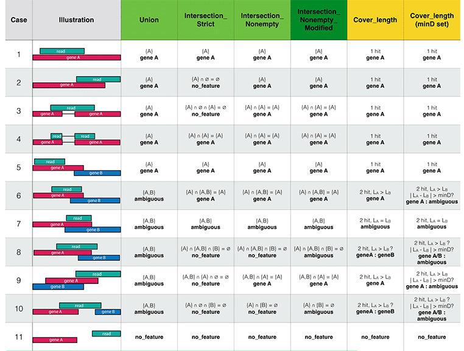

Note the `Intersection_Nonempty_Modified` mode is different from the original HTSeq mode in Case 8 and 10, where it assigns the read to `ambiguous` rather than to `no_feature`. This makes more sense, especially when assigning the reads hierarchically to different feature types.

# 4 Assigning Reads to Multiple Feature Types

Traditional methods require multiple separate runs to assign reads to different feature types. VERSE allows all reads to be assigned to all feature types within a single run. The independent assign scheme produce the same results as traditional methods, while hierarchical scheme assign reads sequentially to each feature type according to their priority, as illustrated in the figures below.

To use multiple feature type assignment, VERSE require the input annotation file to be a combined annotation with all feature types included.

## 4.1 Independent Assign

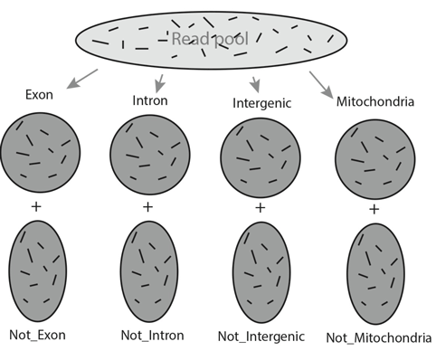

Assigned Exon + Assigned Intron + Assigned Intergenic + Assigned Mitochondria + Ambiguous + No_feature ≠ Total # of reads

## 4.2 Hierarchical Assign

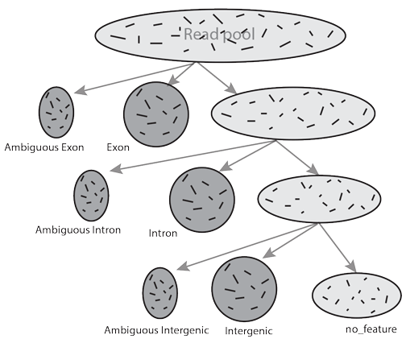

Assigned Exon + Assigned Intron + Assigned Intergenic + Assigned Mitochondria + Ambiguous + No_feature = Total # of reads

Feature type at the first level (e.g., exon) will obtain the same gene counts as the independent assign scheme. Feature type at lower level (e.g., intron) in the hierarchy will get less counts, but since reads assigned to exons has already been removed, quantification at lower level will get less false positives.

The design of the hierarchy thus is extremely important and should address the main research interest.

# 5 Other Details

- Current version of VERSE only support gene level quantification. Overlapping exons of the same gene will be merged to yield accurate gene counts, as shown in the figure below.

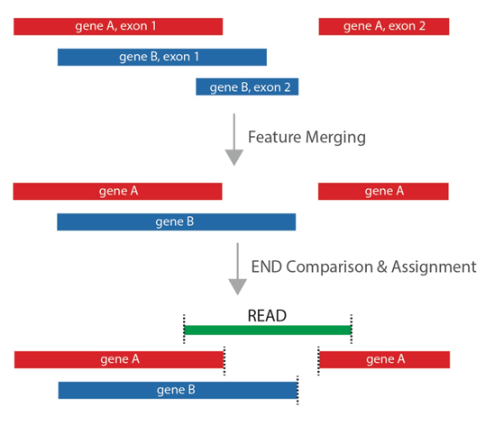

- Current version of VERSE only support quantification of uniquely mapped reads, since most efforts to rescue the multimapping reads often leads to inaccurate gene expression quantification.
- For techinical support, feel free to contact Qin Zhu (qinzhu@outlook.com).